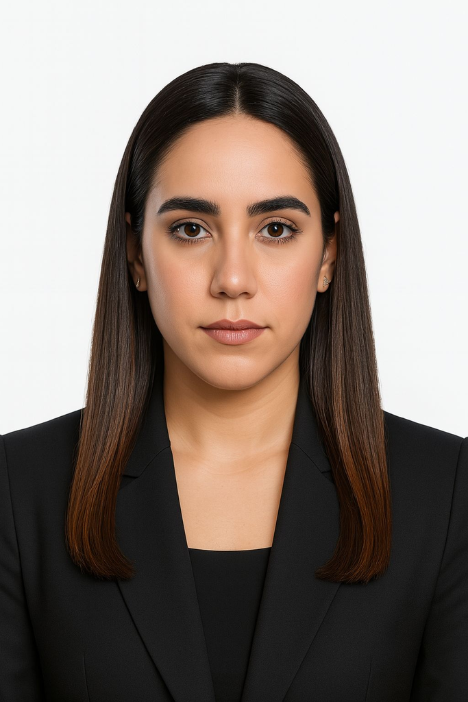

Headshot

# Michelle Marie Ricart

MBA Candidate · University Canada West (UCW)

Vancouver, BC · itsmichricartn@gmail.com · 236-412-0833

Download Resume

*LLM-assisted drafting noted. Full attribution and commentary in the Appendix.*

## About

MBA candidate at **University Canada West** with hands-on experience across **Human Resources** (Compensation & Benefits, employee services, onboarding) and recent **culinary operations** roles in Vancouver. I bring a service mindset, attention to detail, and adaptability developed in high-volume environments—focused on clear communication, process reliability, and people-centric results.

## Education

- **MBA (in progress)** — University Canada West (UCW)
- **Pathway III (Proficiency)** — International Language Academy of Canada (ILAC), Jul 2024
- **B.Sc. in Industrial Psychology** — Universidad Pedro Henríquez Ureña (UNPHU), Apr 2023

## Professional Highlights

### Human Resources — Shell (Santo Domingo, Dominican Republic)

- **Compensation & Benefits Analyst** (Dec 2021 – Sep 2024)
  - Responded to employee inquiries on benefits, payroll, and labour policies, improving service satisfaction.
  - Coordinated with the Ministry of Labour to streamline documentation and deposit procedures.
  - Increased efficiency and timeliness of labour certifications and official documentation.
- **General Analyst** (Dec 2021 – Aug 2024)
  - Delivered front-line support to employees and external partners with a customer-first approach.
  - Managed recruitment, onboarding and training processes to ensure positive new-hire experiences.
  - Led employee orientation programs to strengthen engagement and productivity.

### Culinary & Hospitality — Vancouver, Canada

- **Cook, Guilt and Co** (Oct 2025 – Present)
  - Ensure ingredient quality and station organization; execute dishes and prep to standard.
- **Line Cook, Six Acres** (Mar 2025 – May 2025)
  - Maintain quality control and cleanliness; complete assigned dishes and prep.
- **Plater, Fed** (Mar 2025 – Sep 2025)
  - Plate accurately, portion correctly, and present food attractively.
- **Stock Service, ZARA** — Santo Domingo, Dominican Republic (Nov 2019 – Nov 2021)
  - Stock control, inventories, order prep, and ERP updates to maintain availability.

## Skills

Teamwork Problem-Solving Customer Service Attention to Detail Interpersonal Skills Adaptability Time Management

## Contact

- 📍 Vancouver, BC, Canada
- ✉️ itsmichricartn@gmail.com
- 📞 +1 236‑412‑0833
- 🔗 [LinkedIn](https://www.linkedin.com/in/michelle-marie-ricart-naranjo-042628199/)

© Oct 22, 2025 · Built with [Quarto](https://quarto.org/). · Appendix